# An introduction to the rSPDE package

David Bolin and Alexandre B. Simas

2021-12-12

## Introduction

In this vignette we will provide a brief introduction to the `rSPDE` package by providing a simple data set and using the different functions in the package to analyze it.

We have two main “families” of functions inside the `rSPDE` package:

- The `R-INLA` implementation of the rational SPDE approach;
- The rational SPDE approach.

We will analyze the same data set using both approaches. We also have specific vignettes for each of the aforementioned family. More precisely, we have the following additional vignettes:

- R-INLA implementation of the rational SPDE approach
- Rational approximation with the rSPDE package

We also have a separate group of functions for performing operator-based rational approximations. These will be useful when performing rational approximations for fractional SPDE models with non-Gaussian noise. A example in which such approximation is suitable is when one has the so-called type G Lévy noises.

We refer the reader to [Geostatistical Modelling Using Non-Gaussian Matérn Fields](https://onlinelibrary.wiley.com/doi/full/10.1111/sjos.12141), [Spatial Matérn Fields Driven by Non-Gaussian Noise](https://onlinelibrary.wiley.com/doi/abs/10.1111/sjos.12046) and [Linear mixed effects models for non-Gaussian continuous repeated measurement data](https://rss.onlinelibrary.wiley.com/doi/pdf/10.1111/rssc.12405) for examples of models driven by type-G Lévy noises. We also refer the reader to the [`ngme` package](https://github.com/davidbolin/ngme) where one can fit such models.

We explore the functions for performing the operator-based rational approximation on the vignette:

- Operator-based rational approximation with the rSPDE package

## A toy data set

We begin by creating a toy data set.

For this illustration, we will simulate a data set on a two-dimensional spatial domain. To this end, we need to construct a mesh over the domain of interest and then compute the matrices needed to define the operator. We will use the `R-INLA` package to create the mesh and obtain the matrices of interest.

We will begin by defining a mesh over $[0,1]\times [0, 1]$:

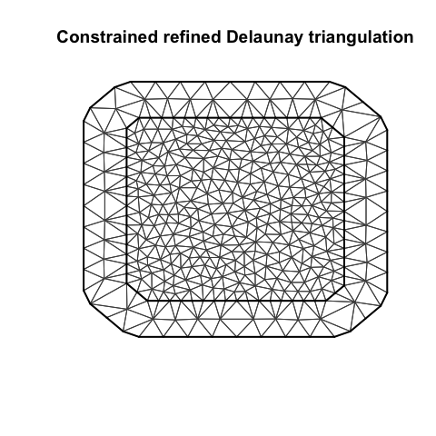

```r
library(INLA)
m =500
loc_2d_mesh = matrix(runif(m*2),m,2)
mesh_2d = inla.mesh.2d(
  loc=loc_2d_mesh,
  cutoff=0.05,
  max.edge=c(0.1,0.5) )
plot(mesh_2d)
```

We will now use the `matern.operators` function to construct a rational SPDE approximation of order $m=2$ for a Gaussian random field with a Matérn covariance function on $[0,1]\times [0, 1]$. We choose $\nu=0.5$ which corresponds to exponential covariance. We also set $\sigma=1$ and the range as $0.2$.

```r
library(rSPDE)
sigma = 1
range = 0.2
nu <- 0.5
kappa = sqrt(8*nu)/range
op <- matern.operators(mesh=mesh_2d,nu=nu,
                                   kappa=kappa,sigma=sigma,m=2)
```

We are now in a position to simulate the latent field. We will simulate the latent field $u$:

```r
u <- simulate(op)
```

We now obtain a realization of $y$. To construct the observation matrix, we use the `R-INLA` function `inla.spde.make.A()`.

```r
A <- inla.spde.make.A(
  mesh=mesh_2d,
  loc=loc_2d_mesh)
sigma.e <- 0.1
y = A %*% u + rnorm(m) * sigma.e
```

The observed data can be seen in the following image.

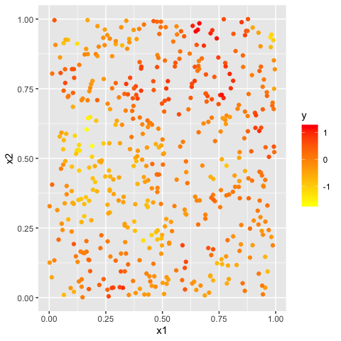

The simulated random field is shown in the following figure.

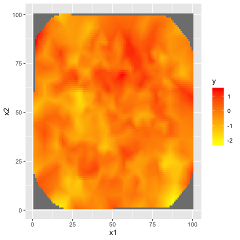

## Fitting the model with `R-INLA` implementation of the rational SPDE approach

We will now fit the model of the toy data set using our `R-INLA` implementation of the rational SPDE approach. Further details on this implementation can be found in R-INLA implementation of the rational SPDE approach.

We begin by creating the $A$ matrix, the index, and the `inla.stack` object.

```r
Abar <- rspde.make.A(mesh = mesh_2d, loc = loc_2d_mesh)
mesh.index <- rspde.make.index(name = "field", mesh = mesh_2d)

st.dat=inla.stack(
  data=list(y=as.vector(y)),
  A=Abar,
  effects=mesh.index)
```

We now create the model object. We need to set an upper bound for the smoothness parameter $\nu$. When we increase the upper bound for $\nu$ we also increase the computational cost. For this example we set `nu_upper_bound=1`. See the R-INLA implementation of the rational SPDE approach for further details.

```r
rspde_model <- rspde.matern(mesh = mesh_2d,
                            nu_upper_bound = 1)
```

Finally, we create the formula, taking the replicates into account, and fit:

```r
f =
  y ~ -1 + f(field, model=rspde_model)
rspde_fit =
  inla(f,
       data=inla.stack.data(st.dat),
       family="gaussian",
       control.predictor=
         list(A=inla.stack.A(st.dat)),
       inla.mode = "experimental")
```

We can get the summary:

```r
summary(rspde_fit)
```

```
#>
#> Call:
#>    c("inla(formula = f, family = \"gaussian\", data =
#>    inla.stack.data(st.dat), ", " control.predictor = list(A =
#>    inla.stack.A(st.dat)), inla.mode = \"experimental\")" )
#> Time used:
#>     Pre = 3.42, Running = 22.6, Post = 0.0727, Total = 26.1
#> Random effects:
#>   Name     Model
#>     field RGeneric2
#>
#> Model hyperparameters:
#>                                           mean    sd 0.025quant 0.5quant
#> Precision for the Gaussian observations 83.056 1.072     80.919   83.031
#> Theta1 for field                        -1.559 0.012     -1.581   -1.560
#> Theta2 for field                         2.108 0.012      2.084    2.108
#> Theta3 for field                         0.243 0.014      0.216    0.242
#>                                         0.975quant  mode
#> Precision for the Gaussian observations     85.265 82.97
#> Theta1 for field                            -1.534 -1.56
#> Theta2 for field                             2.131  2.11
#> Theta3 for field                             0.272  0.24
#>
#> Marginal log-Likelihood:  26.48
#> Posterior summaries for the linear predictor and the fitted values are computed
#> (Posterior marginals needs also 'control.compute=list(return.marginals.predictor=TRUE)')
```

and the summary in the user’s scale:

```r
result_fit <- rspde.result(rspde_fit, "field", rspde_model)
summary(result_fit)
```

```
#>           mean         sd 0.025quant 0.5quant 0.975quant     mode
#> tau   0.210119 0.00248226   0.205812 0.210243   0.215538 0.209774
#> kappa 8.223890 0.09578920   8.039620 8.234370   8.415540 8.244290
#> nu    0.559783 0.00342860   0.554124 0.560290   0.567388 0.559762
```

```r
tau <- op$tau
result_df <- data.frame(parameter = c("tau","kappa","nu"),
                        true = c(tau, kappa, nu), mean = c(result_fit$summary.tau$mean,
                                                           result_fit$summary.kappa$mean,
                                                           result_fit$summary.nu$mean),
                        mode = c(result_fit$summary.tau$mode,
                                                           result_fit$summary.kappa$mode,
                                                           result_fit$summary.nu$mode))
print(result_df)
```

```
#>   parameter       true      mean      mode
#> 1       tau  0.2236068 0.2101194 0.2097745
#> 2     kappa 10.0000000 8.2238943 8.2442945
#> 3        nu  0.5000000 0.5597830 0.5597616
```

## Kringing with `R-INLA` implementation of the rational SPDE approach

Let us now obtain predictions (i.e. do kriging) of the latent field on a dense grid in the region.

We begin by creating the grid in which we want to do the predictions. To this end, we can use the `rspde.mesh.projector()` function. This function has the same arguments as the function `inla.mesh.projector()` the only difference being that the rSPDE version also has an argument `nu` and an argument `rspde_order`. Thus, we proceed in the same fashion as we would in INLA’s standard SPDE implementation:

```r
projgrid <- rspde.mesh.projector(mesh_2d, xlim = c(0,1),
ylim = c(0,1))
```

This lattice contains 100 × 100 locations (the default).

Let us plot the locations that we will do prediction:

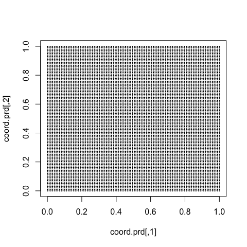

```r
coord.prd <- projgrid$lattice$loc
plot(coord.prd, type = "p", cex = 0.1)
```

Let us now calculate the predictions jointly with the estimation. To this end, first, we begin by linking the prediction coordinates to the mesh nodes through an $A$ matrix

```r
A.prd <- projgrid$proj$A
```

We now make a stack for the prediction locations. We have no data at the prediction locations, so we set `y= NA`. We then join this stack with the estimation stack.

```r
ef.prd = list(c(mesh.index))
st.prd <- inla.stack(data = list(y = NA),
    A = list(A.prd), tag = "prd",
    effects = ef.prd)
st.all <- inla.stack(st.dat, st.prd)
```

Doing the joint estimation takes a while, and we therefore turn off the computation of certain things that we are not interested in, such as the marginals for the random effect. We will also use a simplified integration strategy (actually only using the posterior mode of the hyper-parameters) through the command `control.inla = list(int.strategy = "eb")`, i.e. empirical Bayes:

```r
rspde_fitprd <- inla(f, family = "Gaussian",
             data = inla.stack.data(st.all),
             control.predictor = list(A = inla.stack.A(st.all),
                                      compute = TRUE, link = 1),
             control.compute = list(return.marginals = FALSE,
                                    return.marginals.predictor = FALSE),
             control.inla = list(int.strategy = "eb"))
```

We then extract the indices to the prediction nodes and then extract the mean and the standard deviation of the response:

```r
id.prd <- inla.stack.index(st.all, "prd")$data
m.prd<- matrix(rspde_fitprd$summary.fitted.values$mean[id.prd],100,100)
sd.prd <- matrix(rspde_fitprd$summary.fitted.values$sd[id.prd],100,100)
```

Finally, we plot the results. First the mean:

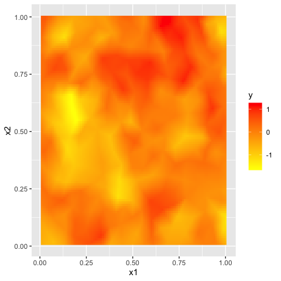

Then, the std. deviations:

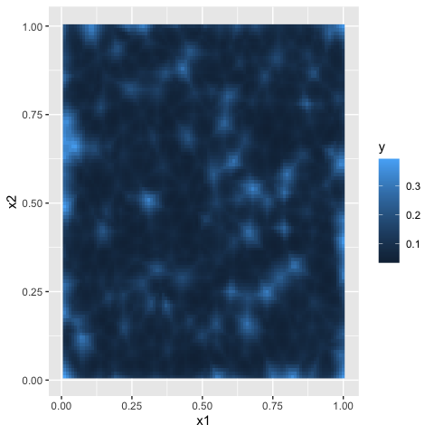

## Fitting the model with `rSPDE`

We will now fit the model of the toy data set without using `R-INLA`. To this end we will use the rational approximation functions from `rSPDE` package. Further details can be found in the vignette Rational approximation with the rSPDE package.

We will now use the function `rSPDE.matern.loglike()` to define the likelihood. This function is object-based, in the sense that it obtains several of the quantities it needs from the `rSPDE` model object.

Notice that we already created a `rSPDE` model object to simulate the data. We will, then, use the same model object. Recall that the `rSPDE` model object we created is `op`. We also already have the $A$ matrix connecting the observation locations to the mesh, and we simply called it `A`.

```r
mlik <- function(theta, Y, A, op) {
  sigma = exp(theta[1])
  kappa = exp(theta[2])
  nu = exp(theta[3])
  return(-rSPDE::rSPDE.matern.loglike(object = op, Y=Y,
                                  A = A, user_kappa=kappa, user_sigma = sigma,
                                 user_nu=nu, sigma.e = exp(theta[4])))
}
```

We can now estimate the parameter using `optimParallel` (one can also use `optim`):

```r
library(optimParallel)
#Preparing the parallel
cl <- makeCluster(detectCores()-1)
setDefaultCluster(cl=cl)

#Fitting the model
theta0 = c(get.inital.values.rSPDE(mesh=mesh_2d),
              log(0.1*sqrt(var(as.vector(y)))))
start_time <- Sys.time()
pars <- optimParallel(theta0, mlik, Y = y, A = A, op=op)
end_time <- Sys.time()
total_time <- end_time - start_time
results <- data.frame(sigma = c(sigma, exp(pars$par[1])),
                      kappa = c(kappa, exp(pars$par[2])),
                      nu = c(nu, exp(pars$par[3])),
                      sigma.e = c(sigma.e, exp(pars$par[4])),
                      row.names = c("True", "Estimate"))
print(results)
```

```
#>          sigma     kappa        nu   sigma.e
#> True         1 10.000000 0.5000000 0.1000000
#> Estimate     1  8.098931 0.5277972 0.1134149
```

```r
#Total time
print(total_time)
```

```
#> Time difference of 4.818748 secs
```

## Kringing with `rSPDE`

We will now do kringing on the same dense grid we did for the `R-INLA`-based rational SPDE approach, but now using the `rSPDE` functions. To this end we will use the `predict` method on the `rSPDE` model object.

Observe that we need an $A$ matrix connecting the mesh to the prediction locations.

Let us now create the $A$ matrix for the same prediction locations we used for the previous case (using the `R-INLA` implementation).

```r
predgrid <- inla.mesh.projector(mesh_2d, xlim = c(0,1),
ylim = c(0,1))
A.prd2 <- predgrid$proj$A
```

We will now use the `predict` method on the `rSPDE` model object with the argument `compute.variances` set to `TRUE` so that we can plot the standard deviations. Let us also update the values of the `rSPDE` model object to the fitted ones, and also save the estimated value of `sigma.e`.

```r
sigma.e.est <- exp(pars$par[4])
op.prd <- update(op, user_sigma = exp(pars$par[1]),
                 user_kappa = exp(pars$par[2]),
                 user_nu = exp(pars$par[3]))

pred.rspde <- predict(op.prd, A = A, Aprd = A.prd2, Y = y,
                      sigma.e = sigma.e.est,
                      compute.variances = TRUE)
```

Finally, we plot the results. First the mean:

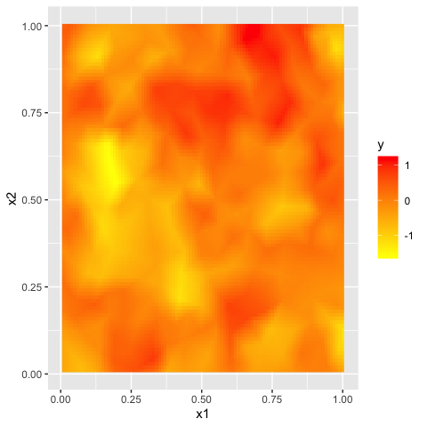

Then, the std. deviations:

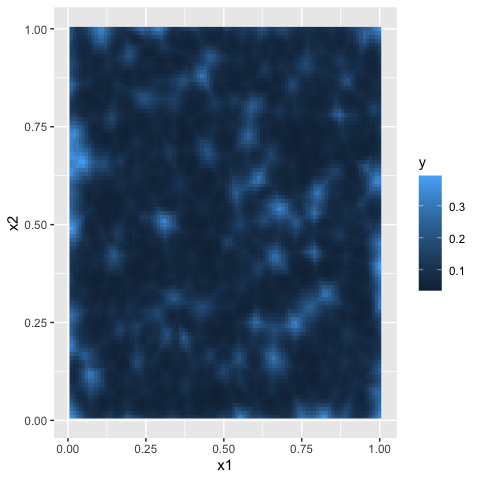

# References

Asar, Özgür, David Bolin, Peter Diggle, and Jonas Wallin. 2020. “Linear Mixed Effects Models for Non‐Gaussian Repeated Measurement Data.” *Journal of the Royal Statistical Society. Series C. Applied Statistics* 69 (5): 1015–65.

Bolin, David. n.d. “Spatial Matérn Fields Driven by Non-Gaussian Noise.” *Scandinavian Journal of Statistics* 41 (3): 557–79.

Bolin, David, and Kristin Kirchner. 2020. “The Rational SPDE Approach for Gaussian Random Fields with General Smoothness.” *Journal of Computational and Graphical Statistics* 29 (2): 274–85.

Lindgren, Finn, Håvard Rue, and Johan Lindström. 2011. “An Explicit Link Between Gaussian Fields and Gaussian Markov Random Fields: The Stochastic Partial Differential Equation Approach.” *Journal of the Royal Statistical Society. Series B. Statistical Methodology* 73 (4): 423–98.

Wallin, Jonas, and David Bolin. 2015. “Geostatistical Modelling Using Non-Gaussian Matérn Fields.” *Scandinavian Journal of Statistics* 42 (3): 872–90.